# Assignment-5

rama krishna

11/29/2021

```r
setwd("C:/Users/krish/OneDrive/Desktop/R_MLCODES/rmullapu_64060")
library(readr)
library(tidyverse)
library(cluster)
library(dplyr)
library(knitr)
library(caret)
library(factoextra)
library(dendextend)
cereals<- read.csv("Cereals.csv")
cereals
```

```
##                                      name mfr type calories protein fat sodium
## 1                               100%_Bran   N    C       70       4   1    130
## 2                       100%_Natural_Bran   Q    C      120       3   5     15
## 3                                All-Bran   K    C       70       4   1    260
## 4               All-Bran_with_Extra_Fiber   K    C       50       4   0    140
## 5                          Almond_Delight   R    C      110       2   2    200
## 6                 Apple_Cinnamon_Cheerios   G    C      110       2   2    180
## 7                             Apple_Jacks   K    C      110       2   0    125
## 8                                 Basic_4   G    C      130       3   2    210
## 9                               Bran_Chex   R    C       90       2   1    200
## 10                            Bran_Flakes   P    C       90       3   0    210
## 11                           Cap'n'Crunch   Q    C      120       1   2    220
## 12                               Cheerios   G    C      110       6   2    290
## 13                  Cinnamon_Toast_Crunch   G    C      120       1   3    210
## 14                               Clusters   G    C      110       3   2    140
```

[output cut: 141 more lines]

# To view if the data has any missing values

```r
#View(cereals)
```

# To remove the missing values present in the data

```r
cdata<- na.omit(cereals)
#view(cdata)
```

#QUESTION 1 Apply hierarchical clustering to the data using Euclidean distance to the normalized measurements. Use Agnes to compare the clustering from single linkage, complete linkage, average linkage, and Ward. Choose the best method. # Normalize the data

```r
cdata_norm <- cbind(cdata[, 1:3], scale(cdata[, -c(1:3)]))
#view(cdata_norm)
```

#Apply hierarchical clustering to the data using Euclidean distance

```r
dist <- dist(cdata, method = "euclidean", diag = FALSE, upper = FALSE, p =2)
#dist
```

#clustering the data and comparing them using agnes

```r
single_clust <- agnes(dist, method = "single")
print(single_clust)
```

```
## Call:     agnes(x = dist, method = "single")
## Agglomerative coefficient:  0.7311616
## Order of objects:
##  [1] 1  4  2  27 44 61 69 64 65 66 55 56 6  19 15 43 38 49 26 11 13 36 77 24 14
## [26] 57 33 42 23 60 20 34 51 16 17 63 32 22 62 41 73 68 9  76 48 75 37 8  50 52
## [51] 7  25 30 74 18 31 67 46 47 28 12 45 10 29 53 59 35 39 70 40 72 71 54 3
## Height (summary):
##    Min. 1st Qu.  Median    Mean 3rd Qu.    Max.
##    1.90   20.64   28.69   36.13   48.28  112.44
##
## Available components:
## [1] "order"     "height"    "ac"        "merge"     "diss"      "call"
## [7] "method"    "order.lab"
```

```r
# the AGGLOMERATIVE COEFFICIENT using single linkage method is 0.7311616
```

```r
complete_clust <- agnes(dist, method = "complete")
print(complete_clust)
```

```
## Call:     agnes(x = dist, method = "complete")
## Agglomerative coefficient:  0.922957
## Order of objects:
##  [1] 1  4  3  10 29 53 59 71 20 60 28 45 46 47 2  65 66 27 44 61 69 64 18 31 67
## [26] 35 55 56 6  19 15 43 77 11 13 36 26 38 49 7  25 30 74 8  50 52 9  76 24 34
## [51] 51 14 57 23 33 42 39 70 40 72 12 37 48 75 16 17 63 32 22 62 68 41 73 54
## Height (summary):
##    Min. 1st Qu.  Median    Mean 3rd Qu.    Max.
##    1.90   22.32   43.77   70.53   84.64  446.26
##
## Available components:
## [1] "order"     "height"    "ac"        "merge"     "diss"      "call"
## [7] "method"    "order.lab"
```

```r
#using complete linkage method the AGGLOMERATIVE COEFFICIENT is 0.922957
```

```r
avg_clust <- agnes(dist, method = "average")
print(avg_clust)
```

```
## Call:     agnes(x = dist, method = "average")
## Agglomerative coefficient:  0.8792621
## Order of objects:
##  [1] 1  4  3  2  27 44 61 69 64 65 66 35 55 56 6  19 15 43 77 26 38 49 11 13 36
## [26] 14 57 23 33 42 24 34 51 52 8  50 9  76 48 75 12 37 16 17 63 32 22 62 68 41
## [51] 73 39 70 40 72 7  25 30 74 18 31 67 10 29 53 59 71 20 60 28 46 47 45 54
## Height (summary):
##    Min. 1st Qu.  Median    Mean 3rd Qu.    Max.
##    1.90   22.32   37.90   54.82   71.16  280.59
##
## Available components:
## [1] "order"     "height"    "ac"        "merge"     "diss"      "call"
## [7] "method"    "order.lab"
```

```r
#using average linkage method the AGGLOMERATIVE COEFFICIENT is 0.8792621
```

```r
ward_clust <- agnes(dist, method = "ward")
print(ward_clust)
```

```
## Call:     agnes(x = dist, method = "ward")
## Agglomerative coefficient:  0.9597071
## Order of objects:
##  [1] 1  4  3  10 29 53 59 71 20 60 28 46 47 45 6  19 15 43 24 77 11 13 36 26 38
## [26] 49 39 70 40 72 8  50 52 9  76 37 48 75 14 57 23 33 42 34 51 7  25 30 74 18
## [51] 31 67 35 12 16 17 63 32 22 62 68 41 73 54 2  65 66 27 44 61 69 64 55 56
## Height (summary):
##    Min. 1st Qu.  Median    Mean 3rd Qu.    Max.
##    1.90   22.89   44.72   96.14   91.98  869.24
##
## Available components:
## [1] "order"     "height"    "ac"        "merge"     "diss"      "call"
## [7] "method"    "order.lab"
```

```r
#using ward linkage method the AGGLOMERATIVE COEFFICIENT is 0.9597071
```

# by comparing the agglomerative coefficient values ward linkage method is the best method.

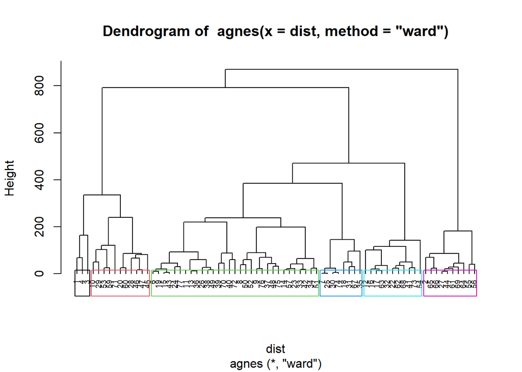

```r
pltree(ward_clust, cex = 0.6, hang = -1)
rect.hclust(ward_clust, k = 6, border = 1:6)
```

```r
Model_1 <- cutree(ward_clust, 6)
data <- cbind(data,Model_1)
```

# QUESTION 3 cluster structure and stability

# Cluster partition A

```r
set.seed(123)
dataA_index <- sample(seq_len(nrow(cdata_norm)), size = 67)
dataA <- cdata_norm[dataA_index,]
dataB <- cdata_norm[-dataA_index,]
dataA
```

```
##                                      name mfr type   calories    protein
## 33                      Grape_Nuts_Flakes   P    C -0.3541153  0.4522084
## 53                  Post_Nat._Raisin_Bran   P    C  0.6537514  0.4522084
## 15                            Cocoa_Puffs   G    C  0.1498180 -1.4068705
## 70                      Total_Corn_Flakes   G    C  0.1498180 -0.4773310
## 44                                  Maypo   A    H -0.3541153  1.3817478
## 52                   Oatmeal_Raisin_Crisp   G    C  1.1576848  0.4522084
## 45       Muesli_Raisins,_Dates,_&_Almonds   R    C  2.1655516  1.3817478
## 75                             Wheat_Chex   R    C -0.3541153  0.4522084
## 27                    Frosted_Mini-Wheats   K    C -0.3541153  0.4522084
## 60                        Raisin_Nut_Bran   G    C -0.3541153  0.4522084
## 30                         Fruity_Pebbles   P    C  0.1498180 -1.4068705
## 68                              Special_K   K    C  0.1498180  3.2408266
## 10                            Bran_Flakes   P    C -0.8580487  0.4522084
## 31                           Golden_Crisp   P    C -0.3541153 -0.4773310
```

[output cut: 189 more lines]

```r
dataA_dist <- dist(dataA[, -c(1:3)], method = "euclidean")
hc_A <- hclust(dataA_dist, method = "ward.D")
Model_A <- cutree(hc_A, 6)
dataA <- cbind(Model_A, dataA)
head(dataA)
```

```
##    Model_A                  name mfr type   calories    protein       fat
## 33       1     Grape_Nuts_Flakes   P    C -0.3541153  0.4522084 0.0000000
## 53       2 Post_Nat._Raisin_Bran   P    C  0.6537514  0.4522084 0.0000000
## 15       3           Cocoa_Puffs   G    C  0.1498180 -1.4068705 0.0000000
## 70       4     Total_Corn_Flakes   G    C  0.1498180 -0.4773310 0.0000000
## 44       5                 Maypo   A    H -0.3541153  1.3817478 0.0000000
## 52       2  Oatmeal_Raisin_Crisp   G    C  1.1576848  0.4522084 0.9932203
##         sodium      fiber       carbo     sugars      potass   vitamins
## 33 -0.27020566  0.3401532  0.06944832 -0.4836096 -0.19065695 -0.1818422
## 53  0.45469653  1.5780879 -0.95838683  1.5810314  2.27835060 -0.1818422
## 15  0.21306247 -0.8977815 -0.70142805  1.3516269 -0.61391539 -0.1818422
## 70  0.45469653 -0.8977815  1.61120105 -0.9424187 -0.89608768  3.1822385
## 44 -1.96164410 -0.8977815  0.32640711 -0.9424187 -0.04957081 -0.1818422
## 52  0.09224544 -0.2788141 -0.31598986  0.6634132  0.30314456 -0.1818422
##         shelf     weight       cups     rating
## 33  0.9419715 -0.2008324  0.2476647  0.6915569
## 53  0.9419715  1.9501886 -0.6432404 -0.3228791
## 15 -0.2598542 -0.2008324  0.7567534 -1.3991551
## 70  0.9419715 -0.2008324  0.7567534 -0.2516826
## 44 -0.2598542 -0.2008324  0.7567534  0.8892251
## 52  0.9419715  1.4287290 -1.3644493 -0.8494505
```

```r
C1 <- colMeans(dataA[dataA$Model_A == 1,5:ncol(dataA)])
C2 <- colMeans(dataA[dataA$Model_A == 2,5:ncol(dataA)])
C3 <- colMeans(dataA[dataA$Model_A == 3,5:ncol(dataA)])
C4 <- colMeans(dataA[dataA$Model_A == 4,5:ncol(dataA)])
C5 <- colMeans(dataA[dataA$Model_A == 5,5:ncol(dataA)])
C6 <- colMeans(dataA[dataA$Model_A == 6,5:ncol(dataA)])
Centroids_A <- rbind(C1, C2, C3, C4, C5, C6)
dist <- dist(rbind(Centroids_A,dataB[,4:ncol(dataB)]))
dist
```

```
##          C1       C2       C3       C4       C5       C6        3        4
## C2 3.087519
## C3 3.171116 3.766283
## C4 4.080860 4.394851 4.465807
## C5 3.120031 5.017983 4.225386 5.574752
## C6 3.992549 5.064938 3.600257 4.537638 4.243322
## 3  5.001063 6.043032 7.197863 7.486394 6.477277 7.838851
## 4  7.300259 8.670076 9.647012 9.528843 7.407964 9.662959 4.031051
## 35 2.937467 3.483268 4.492378 5.395800 4.485411 5.823893 5.940473 8.282237
## 42 2.116481 3.253686 3.177192 4.677708 3.523530 4.044877 5.449421 7.913299
## 55 5.871507 8.431790 6.391470 8.139591 4.910302 6.737769 8.695724 9.343676
## 56 5.617653 8.188194 6.445799 8.129250 4.710236 6.816139 7.916319 8.492807
## 76 3.013139 4.262622 3.278687 4.537729 3.020609 2.070710 6.290066 8.004134
##          35       42       55       56
## C2
## C3
## C4
## C5
## C6
## 3
## 4
## 35
## 42 2.768632
## 55 7.106645 6.462448
## 56 6.861611 6.052896 1.377717
## 76 4.732649 2.856300 6.290658 6.120699
```

#c. Assess how consistent the cluster assignments are compared to the assignments based on all the data.

```r
Assignments<- data.frame(data[-dataA_index, "Model_1"])
Assignments$Model_A <- 0
Assignments[1,2] <- which.max(c(2.462441,3.146983,3.782227,5.983747,4.881300,3.826735))
Assignments[2,2] <- which.max(c(2.312626,3.855177, 4.581339, 8.455727 ,4.827885 ,5.441721))
Assignments[3,2] <- which.max(c(3.437484, 1.869957, 4.404072, 8.395433, 4.851045, 4.429787))
Assignments[4,2] <- which.max(c(3.339714, 1.285089 ,4.752289, 8.059830, 4.687570, 3.657016))
Assignments[5,2] <- which.max(c(3.007575 ,3.930439 ,2.431885, 6.230808, 5.027546, 4.008456))
Assignments[6,2] <- which.max(c(3.159701 ,4.694503 ,4.418982, 6.075311, 4.930370, 3.901197))
Assignments[7,2] <- which.max(c(2.691188 ,3.357138, 4.095313, 6.119492, 4.677708, 2.705759))
Assignments
```

```
##   X3 X4 X35 X42 X55 X56 X76 Model_A
## 1  1  4   4   3   2   2   3       0
## 2 NA  4  NA  NA  NA  NA  NA      NA
## 3 NA  4  NA  NA  NA  NA  NA      NA
## 4 NA  4  NA  NA  NA  NA  NA      NA
## 5 NA  4  NA  NA  NA  NA  NA      NA
## 6 NA  4  NA  NA  NA  NA  NA      NA
## 7 NA  4  NA  NA  NA  NA  NA      NA
```

#The elementary public schools would like to choose a set of cereals to include in their daily cafeterias. Every day a different cereal is offered, but all cereals should support a healthy diet. For this goal, you are requested to find a cluster of “healthy cereals.” Should the data be normalized? If not, how should they be used in the cluster analysis?

```r
healthycereals <- cereals
healthycereals_na <- na.omit(healthycereals)
Clusthealthy <- cbind(healthycereals_na, Model_1)
Clusthealthy[Clusthealthy$Model_1==1,]
```

```
##                        name mfr type calories protein fat sodium fiber carbo
## 1                 100%_Bran   N    C       70       4   1    130    10     5
## 3                  All-Bran   K    C       70       4   1    260     9     7
## 4 All-Bran_with_Extra_Fiber   K    C       50       4   0    140    14     8
##   sugars potass vitamins shelf weight cups   rating Model_1
## 1      6    280       25     3      1 0.33 68.40297       1
## 3      5    320       25     3      1 0.33 59.42551       1
## 4      0    330       25     3      1 0.50 93.70491       1
```

```r
Clusthealthy[Clusthealthy$Model_1==2,]
```

```
##                         name mfr type calories protein fat sodium fiber carbo
## 2          100%_Natural_Bran   Q    C      120       3   5     15     2     8
## 27       Frosted_Mini-Wheats   K    C      100       3   0      0     3    14
## 44                     Maypo   A    H      100       4   1      0     0    16
## 55               Puffed_Rice   Q    C       50       1   0      0     0    13
## 56              Puffed_Wheat   Q    C       50       2   0      0     1    10
## 61            Raisin_Squares   K    C       90       2   0      0     2    15
## 64            Shredded_Wheat   N    C       80       2   0      0     3    16
## 65    Shredded_Wheat_'n'Bran   N    C       90       3   0      0     4    19
## 66 Shredded_Wheat_spoon_size   N    C       90       3   0      0     3    20
## 69   Strawberry_Fruit_Wheats   N    C       90       2   0     15     3    15
##    sugars potass vitamins shelf weight cups   rating Model_1
## 2       8    135        0     3   1.00 1.00 33.98368       2
## 27      7    100       25     2   1.00 0.80 58.34514       2
## 44      3     95       25     2   1.00 1.00 54.85092       2
## 55      0     15        0     3   0.50 1.00 60.75611       2
## 56      0     50        0     3   0.50 1.00 63.00565       2
## 61      6    110       25     3   1.00 0.50 55.33314       2
## 64      0     95        0     1   0.83 1.00 68.23588       2
## 65      0    140        0     1   1.00 0.67 74.47295       2
## 66      0    120        0     1   1.00 0.67 72.80179       2
## 69      5     90       25     2   1.00 1.00 59.36399       2
```

```r
Clusthealthy[Clusthealthy$Model_1==3,]
```

```
##                           name mfr type calories protein fat sodium fiber carbo
## 6      Apple_Cinnamon_Cheerios   G    C      110       2   2    180   1.5  10.5
## 8                      Basic_4   G    C      130       3   2    210   2.0  18.0
## 9                    Bran_Chex   R    C       90       2   1    200   4.0  15.0
## 11                Cap'n'Crunch   Q    C      120       1   2    220   0.0  12.0
## 13       Cinnamon_Toast_Crunch   G    C      120       1   3    210   0.0  13.0
## 14                    Clusters   G    C      110       3   2    140   2.0  13.0
## 15                 Cocoa_Puffs   G    C      110       1   1    180   0.0  12.0
## 19               Count_Chocula   G    C      110       1   1    180   0.0  12.0
## 23      Crispy_Wheat_&_Raisins   G    C      100       2   1    140   2.0  11.0
## 24                 Double_Chex   R    C      100       2   0    190   1.0  18.0
## 26              Frosted_Flakes   K    C      110       1   0    200   1.0  14.0
## 33           Grape_Nuts_Flakes   P    C      100       3   1    140   3.0  15.0
## 34                  Grape-Nuts   P    C      110       3   0    170   3.0  17.0
## 36            Honey_Graham_Ohs   Q    C      120       1   2    220   1.0  12.0
```

[output cut: 49 more lines]

```r
Clusthealthy[Clusthealthy$Model_1==4,]
```

```
##                  name mfr type calories protein fat sodium fiber carbo sugars
## 7         Apple_Jacks   K    C      110       2   0    125     1    11     14
## 18          Corn_Pops   K    C      110       1   0     90     1    13     12
## 25        Froot_Loops   K    C      110       2   1    125     1    11     13
## 30     Fruity_Pebbles   P    C      110       1   1    135     0    13     12
## 31       Golden_Crisp   P    C      100       2   0     45     0    11     15
## 35 Great_Grains_Pecan   P    C      120       3   3     75     3    13      4
## 67             Smacks   K    C      110       2   1     70     1     9     15
## 74               Trix   G    C      110       1   1    140     0    13     12
##    potass vitamins shelf weight cups   rating Model_1
## 7      30       25     2      1 1.00 33.17409       4
## 18     20       25     2      1 1.00 35.78279       4
## 25     30       25     2      1 1.00 32.20758       4
## 30     25       25     2      1 0.75 28.02576       4
## 31     40       25     1      1 0.88 35.25244       4
## 35    100       25     3      1 0.33 45.81172       4
## 67     40       25     2      1 0.75 31.23005       4
## 74     25       25     2      1 1.00 27.75330       4
```

```r
mean(Clusthealthy[Clusthealthy$Model_1==1,"rating"])
```

```
## [1] 73.84446
```

```r
mean(Clusthealthy[Clusthealthy$Model_1==2,"rating"])
```

```
## [1] 60.11492
```

```r
mean(Clusthealthy[Clusthealthy$Model_1==3,"rating"])
```

```
## [1] 37.30956
```

```r
mean(Clusthealthy[Clusthealthy$Model_1==4,"rating"])
```

```
## [1] 33.65472
```

# hence we see that mean value of cluster 1 is high (73.84446), we can choose cluster1